# Positive externalities of a malaria elimination campaign

# Abstract

**BACKGROUND:** A district-wide malaria elimination campaign was carried out in Magude (Southern Mozambique) in 2015 and 2016. The incidence of malaria is known to have reduced drastically in Magude as a result of the intervention, but its effects may go beyond the borders of the intervention area.

**METHODS:** In this study, ordinary least squares and poisson regression models were employed to estimate the effect of the Magude malaria elimination campaign on the weekly incidence of malaria in the five districts which share a border with Magude, using those 13 districts in the Gaza and Maputo provinces which do not share a border with Magude as “controls”. Confounding variables considered in the analysis are precipitation, population coverage with insecticide-treated bed nets (ITN), and indoor residual spray campaigns (IRS), and seasonality.

**CONCLUSION:** Malaria elimination campaigns can have “positive spillover” effects in which the burden of disease is lessened in areas near - but not in - an intervention zone. These effects should be quantified in impact evaluations and cost effectiveness analyses.

**KEYWORDS:** Cost-effectiveness; externalities; malaria; Geographical distribution; Malaria intervention effects

=======================

# Introduction

The purpose of cost-effectiveness analyses is to “systematically compare the costs and consequences of health interventions” (Hanson, 2004). In doing so, one must take a transparent and rigorous approach to defining exactly what constitutes both costs and consequences. Those carrying out these evaluations often encounter relative ease in the estimation of the former, but great difficulty in the estimation of the latter. Whereas costs can be of only a few varities (fixed vs. variable, start-up vs. maintenance) and are generally rigorously tracked in accounting and budgetary systems, understanding consequences requires a great deal more work in defining their scope, time frame and key indicators.

In the case of public health interventions targetting malaria, consequences (or “effectiveness”) take on a myraid of metrics, ranging from DALYS averted (Goodman et al., 1999), to cost-benefit ratios (Shretta et al., 2016), to incremental cost-effectiveness ratios (Lee et al., 2017) (to name just a few). But whatever the indicator, most malaria intervention evaluations share three common weaknesses: they are too limited in time (only assessing immediate, short-term effects); they are too limited in domain (only assessing the consequences in health); and they are too limited in space (not assessing the potential of consequences beyond the zone where the intervention occurred). The limitation of time is relatively insurmountable, since the most robust way to estimate long-term effects accurately is to observe them (ie, wait). Likewise, the limitation of domain is somewhat natural, since certain areas (disease, income, etc.) are more quantifiable than others.

This paper focuses on addressing the third limitation: how to better incorporate the consequences of a health intervention *outside* of the geographic area where the intervention occurred. Fortunately, unlike the previous two limitations, this one is surmountable when routine epidemiologlical surveillance data is used for the evaluation of geography-specific interventions (often the case). By expanding the concept of evaluation beyond the intervention zone’s borders, we can potentially yield insight into the secondary effects of interventions. Doing so means a better accounting of externalities, and a more accurate approach to cost-effectiveness analysis.

Externalities are most often understood, in the context of public health campaigns, to be negative. Concerns are often voiced regarding drug and insecticide resistance (Blasco et al., 2017, Youdom et al. (2017), Aliyu et al. (2017), Chouaïbou et al. (2016)), environmental degradation (Relyea, 2004, Hien et al. (2017), Viljoen et al. (2016)), and even moral hazard (Yilma et al., 2012). In many cases, economists have attempted to quantify and incorporate the costs of these externalities in CEAs. However, rarely is the potential for positive short-term externalities assessed or even acknowledged. When cross-border movement and leakage are referenced, it is usually in the context of threats to public health and masking of intervention effectiveness (Hanson, 2004); in the specific case of malaria intervention, cross-border effects are most often referenced in the context of potential post-elimination disease importation. However, when it comes to malaria, leakage and cross-border effects also have the potential to be positive.

In this paper, we examine the case of a malaria elimination campaign which employed mass drug administration (MDA) as the primary tool in a multi-pronged attempt to eliminate the transmission of malaria in the district of Magude, Mozambique, from late October 2015 through early 2017. The pilot elimination campaign, carried out by the Mozambican Alliance Towards the Elimination of Malaria (MALTEM), consisted of the administration of four rounds of Dihydroartemisinin-Piperaquine, as well as a round of indoor residual spraying (IRS). Further details about the campaign, including the preliminary finding of a significant short-term reduction in the incidence of malaria in Magude district, have been published elsewhere (Brew et al., 2017).

# Methods

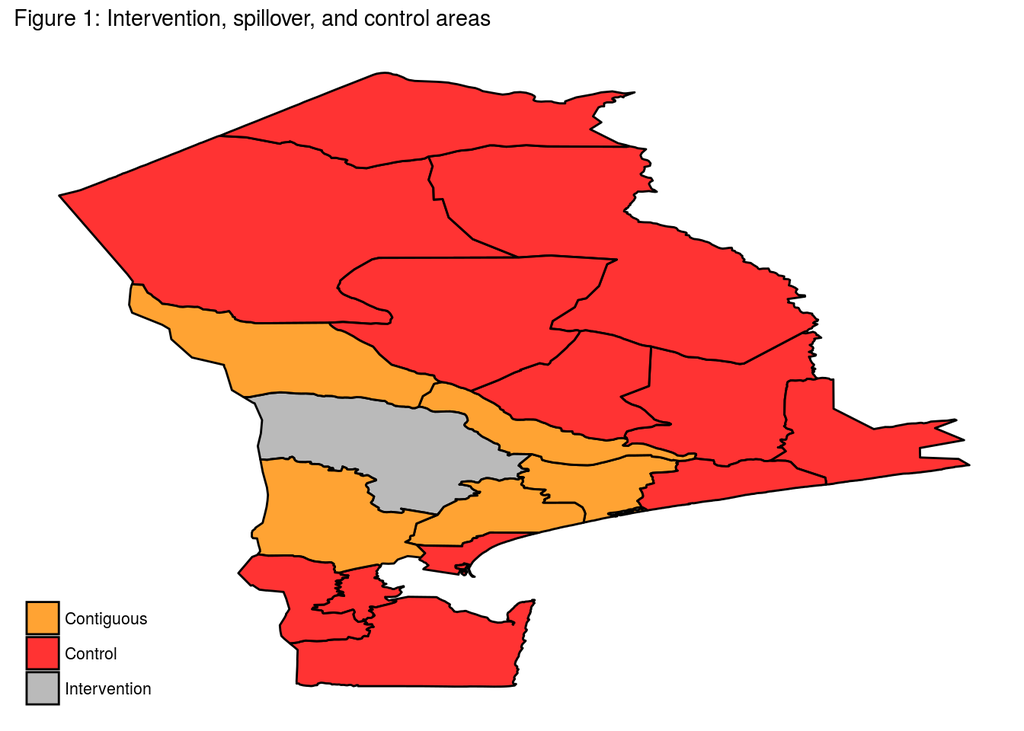

Our analysis consisted of a comparison between the contiguous and control areas both during the period immediately leading up to the intervention (January 1, 2013 through October 10, 2015), as well as the first 1.5 years after the intervention began (October 11, 2015 through March 1, 2017). We intentionally removed from our analysis the period prior to 2013, since data during that time is less reliable and less comparable to the post-intervention period. In a first phase of analysis, we calculate the simple cumulative incidence during both the before and after phases for both locations (contiguous and control). We then assess significance by estimating a simple ordinary least squares regression model on the incidence as a function of the interaction between the binary time period and location categories, as well as month (as a proxy for seasonality).

Though neither the contiguous nor control districts received MDA, other smaller interventions did take place during the study time. Importantly, both IRS campaigns and ITN (insecticide-treated net) distribution activities occurred in some of the contiguous and control districts, at different times, and with different levels of coverage. Therefore, we model the effect of these interventions (both in terms of coverage rates and time since intervention), so as to be able to generate a hypothetical “predicted” number of cases in the contiguous districts, had the malaria elimination not occurred. For the generation of counterfactual predicted values, we employ a multivariate poisson model which estimates the week-specific district-level malaria incidence, trained only on pre-intervention data. Our initial model took on the following form:

$$\begin{equation}
\operatorname{Pr}(\text{Malaria} = 1 \mid \text{X}) = \beta_{0} + \beta_{1} \text{Location} + \beta_{2} \text{Season} + (\beta_3{ITN}*\beta_4ITN_t) + (\beta_5{IRS}*\beta_6{IRS_t})
\end{equation}$$

(where $_t$ represents time elapsed since commencement of most recent IRS or ITN campaign)

Our model accounts for the fixed effects of location and seasonality, as well as the potential confounding effects of population coverage by ITN, and IRS, and the interaction of those latter effects with the time since their initiation (since both have a “waning” effect). Precipitation and lagged precipitation data were collected and analyzed, but were not included in the model due to lack of granularity (there were only negligible differences between different locations). The time elapsed since the most recent indoor residual spraying (IRS) campaign had taken place in the district, as well as the IRS population coverage were initially included as covariates in the model, but removed after backwards stepwise selection.

All data processing and analysis were carried out in R (R Core Team, 2017). All code is freely available online (Brew, 2017).

# Results

## Raw model estimates

| Location | Period | Cases | Person weeks | Avg weekly incidence |
| --- | --- | --- | --- | --- |
| Control | Before | 945534 | 249857242 | 3.78 |
| Control | After | 628984 | 148285896 | 4.24 |
| Contiguous | Before | 542374 | 82173594 | 6.60 |
| Contiguous | After | 252499 | 47397482 | 5.33 |

<sup>a</sup> Unadjusted incidence values

We estimate the simple spillover effect to be a reduction in the weekly incidence of malaria of 1.3 cases per 1,000, with a 95% confidence interval of between 0.63 and 1.97. During the malaria season, the effect is greater: a reduction of 3.94, with a 95% confidence interval of between 2.66 and 5.22.

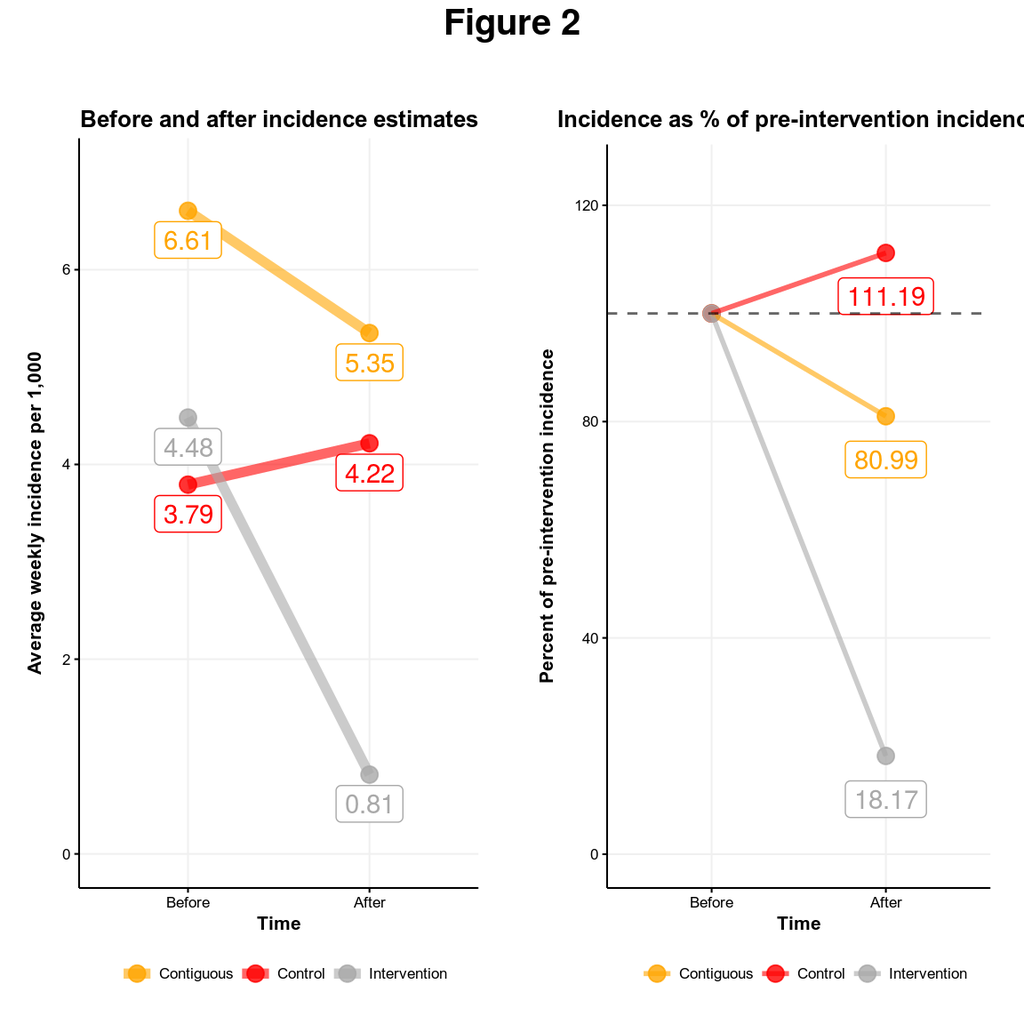

The OLS model estimated for the description of the intervention’s effects on the contiguous area can also be used as a predictive tool for a hypothetical scenario in which the intervention had not occurred (ie, keeping the fixed effects of the location and period, but manually setting the data on which we predict as non-contiguous), allowing for the estimation of cases prevented. Doing so shows that the intervention in Magude was associated with an unadjusted positive spillover of 52,621 cases prevented during the period from October 10, 2015 through March 1, 2017, with a 95% confidence interval of 31,029 to 74,212 cases.

## Adjusted model estimates

Since the occurrence of other malaria interventions (IRS and ITN campaigns), sub-annual seasonality (high vs. low malaria season) and supra-annual secular trends may affect our estimates, a poisson model was constructed to account for these factors. The below chart shows the monthly incidence of malaria (red line) in both the 5 contiguous districts (left panels) and those 13 non-contiguous districts (right panels), as well as the *predicted* monthly incidence for our Poisson model, trained only on data *prior* to the intervention. By limiting the model’s exposure to post-intervention data, we effectively create a realistic counterfactual of what *would* have happened in the five contiguous and 13 non-contiguous districts - adjust for confounders - had the intervention not occurred. Whereas the observed and predicted lines closely track each other in the control districts (upper right panel), there is a sharp divergence in those lines at exactly the moment of intervention initiation in the contiguous districts (upper left). This divergence is more clearly visible in the charts showing the difference between the observed and predicted values (bottom row).

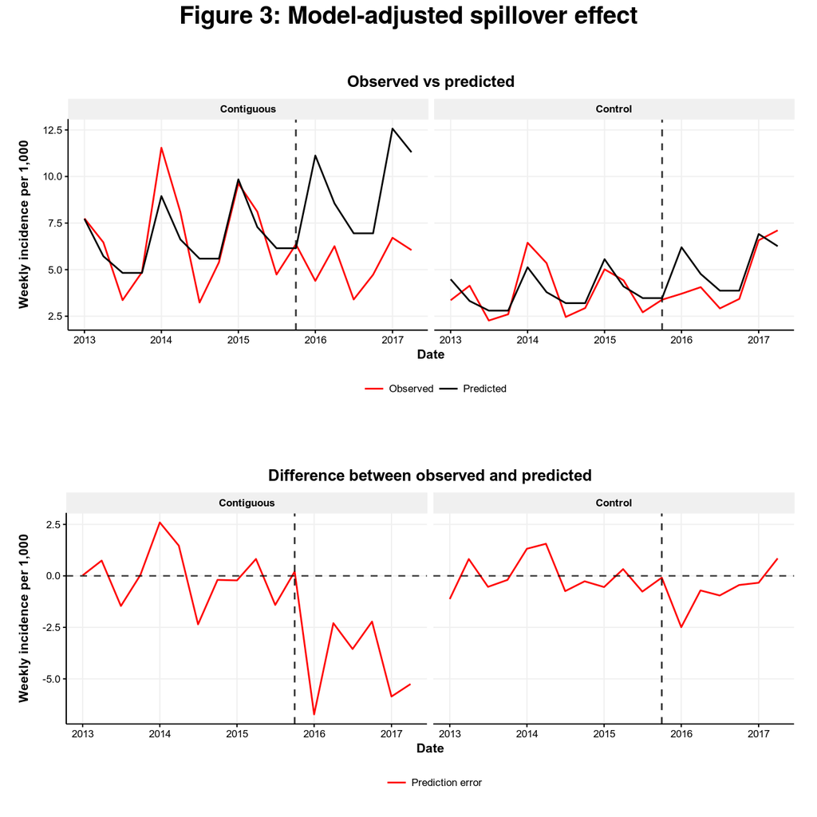

Having demonstrated that the predicted values from the model correctly track the observed values prior to the intervention in both the control and contiguous areas, as well as after the intervention in the control area, we re-train the same model on a full dataset (ie, including post-intervention data). We interact the pre/post intervention variable with the binary location variable so as to quantify the overall adjusted spillover effect of the intervention. Additionally, we exponentiate term coefficients so as to estimate incident rate ratios and, as is best practice with Poisson models, employ robust standard errors in the quantification of uncertainty (Arellano, 2009).

The below table shows model output.

| Term | Coefficient | Robust SE | Incident rate ratio | CI (lower) | CI (upper) |
| --- | --- | --- | --- | --- | --- |
| (Intercept) | -5.7556848 | 0.0001107 | 0.0031647 | 0.0029551 | 0.0033893 |
| seasonrainy | 0.4334720 | 0.0584032 | 1.5426041 | 1.4322780 | 1.6614286 |
| periodPost | 0.0884728 | 0.0621986 | 1.0925045 | 0.9771509 | 1.2214758 |
| locationContiguous | 0.5552962 | 0.0667474 | 1.7424570 | 1.6164227 | 1.8783184 |
| itn_coverage | 0.0005080 | 0.0006416 | 1.0005081 | 0.9992514 | 1.0017665 |
| periodPost:locationContiguous | -0.3161461 | 0.0512141 | 0.7289529 | 0.6351779 | 0.8365724 |

<sup>a</sup> Regression output for full, adjusted poisson model

After adjustment, the intervention’s effect on the contiguous area was a reduction in the weekly incidence rate by 27.1% (95% confidence interval of 16.34 to 36.48%).

# Discussion

An intervention being associated with a 27 in the weekly incidence rate of malaria in a large area which was *not* part of the intervention zone is, unto itself, an important finding. Though the possibility of positive spillover is certainly not counterintuitive, the magnitude of the result is surprising. If such large spillover effects can be detected in other malaria elimination campaigns, it may be that most evaluations are under-estimating their “overall” effectiveness in two ways: first, they are not counting the many cases averted in nearby geographies; second, they are in some cases comparing with those same nearby geographies to estimate effectiveness. This has scientific implications, but also practical ones - the elimination campaign in Magude, for instance, is a pilot program meant to generate evidence which is usable by the national Ministry of Health for nationwide elimination. For the purposes of planning and budgeting, the potential underestimation of positive spillover can have important implications, especially since the expansion of a district-wide program to a national one would likely see a “snowballing” effect in terms of positive spill-over (ie, positive spillover may be greater than the sum of its parts).

Cost effectiveness analyses, particularly, should take into account the potential for positive spillover, and attempt to quantify it when relevant to the ratios being calculated. For some health interventions, of course, the possibility of positive spillover does not necessarily mean it should be costed - depending on the budgetary source and aims of the intervention, some cases are simply externalities, and intentionally so. However, in the case of many interventions (malaria elimination campaigns included), these externalities should be made internal to the framework through which we understand an intervention’s effectiveness and cost-effectivneness.

Though our study examined the secondary effects of a relatively small campaign (one district in Mozambique), it is our hope that the results may be informative - at a policy level - to decision-makers involved in regional and national malaria elimination campaigns. Specifically, and especially if our results are confirmed in other geogrpahic areas and campaigns, the finding of significant positive spillover should foster cooperation between governments and health interventions, since the beneficiaries go beyond those explicitly targetted. This has important consequences in the case of the global malaria eradication campaign, since border regions pose a particular challenge.

Our study is not without weaknesses. First, we rely exclusively on clinical survelilance data. This may be biased regionally by differential practices in health-seeking behavior, and it is unknown to what extent clinical incidence is a perfect proxy for community incidence. Second, we only examine one intervention. Though our results are statistically significant, additional analyses of different malaria elimination campaigns will shed light on the extent to which our results are generalizable. Further studies can also shed light on the extent to which positive spillover effects are moderated by disease type and transmission modes, geography, and population behavior and density.

This study establishes important evidence regarding the phenomenon of positive spillover in a malaria elimination campaign. We believe that policy-makers, public health practitioners and economists working to evaluate or plan malaria elimination campaigns should be aware of the potential for positive spillover, and should take its effects into account, particularly in the case of “scaling-up” inteventions from pilot projects and trials to national policy.

# References

Aliyu, M., Nasir, I., Umar, Y., Vanstawa, A., Medugu, J., Emeribe, A., Amadu, D., 2017. Prevalence, risk factors, and antimalarial resistance patterns of falciparum plasmodiasis among pregnant women in Kaduna metropolis, Nigeria. Tzu Chi Medical Journal 29, 98–103. doi:10.4103/tcmj.tcmj_22_17

Arellano, M., 2009. PRACTITIONERS’ CORNER: Computing robust standard errors for within-groups estimators. Oxford Bulletin of Economics and Statistics 49, 431–434. doi:10.1111/j.1468-0084.1987.mp49004006.x

Blasco, B., Leroy, D., Fidock, D.A., 2017. Antimalarial drug resistance: Linking plasmodium falciparum parasite biology to the clinic. Nature Medicine 23, 917–928. doi:10.1038/nm.4381

Brew, J., 2017. Positive externalities in malaria elimination. GitHub repository.

Brew, J., Cirera, L., Thomas, R., Sicuri, E., 2017. The short term impact of a malaria elimination campaign in southern mozambique: Evidence from a quasi-experimental approach applied to routine surveillance data.

Chouaïbou, M.S., Fodjo, B.K., Fokou, G., Allassane, O.F., Koudou, B.G., David, J.-P., Antonio-Nkondjio, C., Ranson, H., Bonfoh, B., 2016. Influence of the agrochemicals used for rice and vegetable cultivation on insecticide resistance in malaria vectors in southern côte d’Ivoire. Malaria Journal 15. doi:10.1186/s12936-016-1481-5

Goodman, C., Coleman, P., Mills, A., 1999. Cost-effectiveness of malaria control in sub-saharan africa. The Lancet 354, 378–385. doi:10.1016/s0140-6736(99)02141-8

Hanson, K., 2004. Public and private roles in malaria control: The contributions of economic analysis. The American Journal of Tropical Medicine and Hygiene 71, 168–173.

Hien, A.S., Soma, D.D., Hema, O., Bayili, B., Namountougou, M., Gnankiné, O., Baldet, T., Diabaté, A., Dabiré, K.R., 2017. Evidence that agricultural use of pesticides selects pyrethroid resistance within anopheles gambiae s.l. populations from cotton growing areas in burkina faso, west africa. PLOS ONE 12, e0173098. doi:10.1371/journal.pone.0173098

Lee, B.Y., Zenkov, E., Chatterjee, C., Candrinho, B., Zhang, S., Colborn, J., Briët, O.J.T., Brown, S.T., Mendis, C., Bartsch, S.M., Viisainen, K., DePasse, J.V., Stone, N.T.B., 2017. The economic value of long-lasting insecticidal nets and indoor residual spraying implementation in mozambique. The American Journal of Tropical Medicine and Hygiene 96, 1430–1440. doi:10.4269/ajtmh.16-0744

R Core Team, 2017. R: A language and environment for statistical computing. R Foundation for Statistical Computing, Vienna, Austria.

Relyea, R.A., 2004. Synergistic impact of malathion and predatory stress on six species of north american tadpoles. Environmental Toxicology and Chemistry 23, 1080. doi:10.1897/03-259

Shretta, R., Avanceña, A.L.V., Hatefi, A., 2016. The economics of malaria control and elimination: A systematic review. Malaria Journal 15. doi:10.1186/s12936-016-1635-5

Viljoen, I.M., Bornman, R., Bouwman, H., 2016. DDT exposure of frogs: A case study from limpopo province, south africa. Chemosphere 159, 335–341. doi:10.1016/j.chemosphere.2016.06.023

Yilma, Z., Kempen, L. van, Hoop, T. de, 2012. A perverse “net” effect? Health insurance and ex-ante moral hazard in ghana. Social Science & Medicine 75, 138–147. doi:10.1016/j.socscimed.2012.02.035

Youdom, S.W., Tahar, R., Basco, L.K., 2017. Comparison of anti-malarial drugs efficacy in the treatment of uncomplicated malaria in african children and adults using network meta-analysis. Malaria Journal 16. doi:10.1186/s12936-017-1963-0